# Estudis d'Informàtica, Multimedia i Telecomunicacions

# Mineria de dades: PRA2 - Projecte de mineria de dades

Autor: Cristina Espasa Cárdenas

Maig 2025

# 1 Enunciat

Com a continuació de l’estudi iniciat a la Pràctica 1, procedim a **aplicar models analítics, tant no supervisats com supervisats**, sobre el joc de dades seleccionat i preparat. En aquesta **Pràctica 2 haureu de carregar les dades prèviament preparades a la Pràctica 1**.

L’objectiu és que poseu en pràctica amb les vostres pròpies dades tots els models no supervisats i supervisats que s’han utilitzat a les 3 PACs prèvies. A més, es proposa que s’utilitzin mètriques i algorismes alternatius als proposats a les PACs ja realitzades.

**Punt comú per a tots els exercicis**

En tots els apartats dels exercicis d’aquesta pràctica es demana a l’estudiant, a més d’aplicar els diferents mètodes, analitzar correctament el problema, **detallar-ho de manera exhaustiva**, ressaltant el perquè i com s’ha realitzat, incloure elements visuals, explicar els resultats i fer les comparatives oportunes amb les seves conclusions.

Per a tota la pràctica és **necessari documentar** cada apartat de l’exercici pràctic que s’ha fet, el perquè s’ha fet i com s’ha fet. Així mateix, totes les decisions i conclusions hauran de ser presentades de forma raonada i clara, **contextualitzant els resultats**, és a dir, especificant tots i cadascun dels passos que s’hagin dut a terme per resoldre’ls.

D’aquesta manera es demana a l’estudiant que completi els passos següents amb el joc de dades preparat a la Practica 1:

**Models no supervisats**

1. Aplicar l’algorisme **no supervisat** *k-means* basat en el concepte de distància entre les mitjanes dels grups, sobre el joc de dades originals i les dades normalitzades. Es recorda que cal utilitzar les variables quantitatives o binàries que formin part de la base de dades. També, en aquest apartat cal decidir si els grups es defineixen a partir de les variables normalitzades o no i cal seleccionar el nombre de clústers que millor s’ajusti a les dades.
2. Utilitzant el nombre de clústers i les dades (normalitzades o no) seleccionades al punt 1, utilitzar l’algorisme *k-medians* (basat en les medianes com a centres dels clústers) per definir cadascun dels grups. Compareu els resultats obtinguts amb ambdós algorismes, *k-means* i *k-medians*, i comenteu quin mètode us sembla el més adequat per a les vostres dades. Tingueu en compte que l’algorisme basat en la mediana no és el mateix que l’*around medoids*, que s’implementa amb la funció `pam()` del paquet “cluster” de R. Per tant, addicionalment també podeu comparar els resultats amb els obtinguts amb el mètode *around medoids*.
3. Entrenar de nou el model basat en *k-means* que heu seleccionat al punt 1 però usant una **mètrica de distància diferent a la distància euclidiana** i compareu els resultats.
4. Utilitzar els algorismes **DBSCAN**, provant amb diferents valors del paràmetre `eps` i `minPts`, i comparar els resultats amb els mètodes anteriors. Comenteu si el nombre de clústers coincideix amb el punt 1 i si els casos que els formen són similars.

**Models supervisats**

5. Seleccionar una mostra d’entrenament i una de test utilitzant les proporcions que es considerin més adequades en funció de la disponibilitat de dades. Justificar aquesta selecció.
6. Un cop definida la variable objecte que es vol predir, aplicar un model de generació de regles a partir de **arbres de decisió** i ajustar les diferents opcions (mida mínima dels nodes, criteris de divisió, …) per al seu obtenció. Obtenir l’arbre sense i amb opcions de poda. Obtenir la matriu de confusió. Finalment, comparar els resultats obtinguts amb opcions de poda i sense. Alternativament, si la variable objecte destudi és quantitativa pura sobtenen els criteris d’error que ens permetin determinar la capacitat predictiva.
7. Aplicar un **model supervisat** diferent del punt 6 (pot ser un algorisme d’arbres de decisió diferent o un altre algorisme supervisat alternatiu). Compareu el resultat amb el model generat anteriorment. Es poden utilitzar els criteris d’avaluació de models descrits al material docent de l’assignatura.
8. Identificar eventuals **limitacions** del dataset seleccionat i **analitzar els riscos** en el cas de fer servir el model per classificar un nou cas. Per exemple, pot haver-hi dificultats de sobreajustament, en el cas de classificar, els percentatges de falsos positius i falsos negatius són similars, etc..

**NOTA IMPORTANT:** *Recordeu que si les variables a la vostra base de dades tenen unitats de mesura molt diferents és recomanable transformar les variables per evitar l’efecte escala a causa de les diferents unitats de mesura.*

# 2 Recursos de programació

- Incloem en aquest apartat una llista de recursos de programació per a mineria de dades on podreu trobar exemples, idees i inspiració:
  - [Espai de recursos UOC per a ciència de dades](http://datascience.recursos.uoc.edu/es/)
  - [Cercador de codi R](https://rseek.org/)
  - [Col·lecció de cheatsheets en R](https://rstudio.com/resources/cheatsheets/)

# 3 Data de lliurament

La data límit de lliurament és el 11/06/2025.

# 4 RESPOSTES

En aquest treball hem escollit la base de dades Mall Customers, disponible públicament a Kaggle (https://www.kaggle.com/datasets/vjchoudhary7/customer-segmentation-tutorial-in-python?), que conté informació sobre els clients d’un centre comercial, incloent-hi variables com el gènere, l’edat, els ingressos anuals i una puntuació de despesa (Spending Score). Aquesta base de dades s’ha escollit perquè és senzilla, ben estructurada i permet aplicar tant tècniques de modelatge supervisat com no supervisat, facilitant l’exploració de patrons de comportament i la creació de perfils de clients.

```r
df <- read.csv("Mall_Customers.csv")

# Verificar tipus i NA
str(df); summary(df)
```

```
## 'data.frame':    200 obs. of  5 variables:
##  $ CustomerID            : int  1 2 3 4 5 6 7 8 9 10 ...
##  $ Gender                : chr  "Male" "Male" "Female" "Female" ...
##  $ Age                   : int  19 21 20 23 31 22 35 23 64 30 ...
##  $ Annual.Income..k..    : int  15 15 16 16 17 17 18 18 19 19 ...
##  $ Spending.Score..1.100.: int  39 81 6 77 40 76 6 94 3 72 ...
```

```
##    CustomerID        Gender               Age        Annual.Income..k..
##  Min.   :  1.00   Length:200         Min.   :18.00   Min.   : 15.00
##  1st Qu.: 50.75   Class :character   1st Qu.:28.75   1st Qu.: 41.50
##  Median :100.50   Mode  :character   Median :36.00   Median : 61.50
##  Mean   :100.50                      Mean   :38.85   Mean   : 60.56
##  3rd Qu.:150.25                      3rd Qu.:49.00   3rd Qu.: 78.00
##  Max.   :200.00                      Max.   :70.00   Max.   :137.00
##  Spending.Score..1.100.
##  Min.   : 1.00
##  1st Qu.:34.75
##  Median :50.00
##  Mean   :50.20
##  3rd Qu.:73.00
##  Max.   :99.00
```

```r
# Seleccionar només variables numèriques
mall_num <- df %>% select(Age, Annual.Income..k.., Spending.Score..1.100.) %>% na.omit()

# Normalitzar
mall_norm <- scale(mall_num) %>% as.data.frame()
```

## 4.1 Exercici 1 (20%)

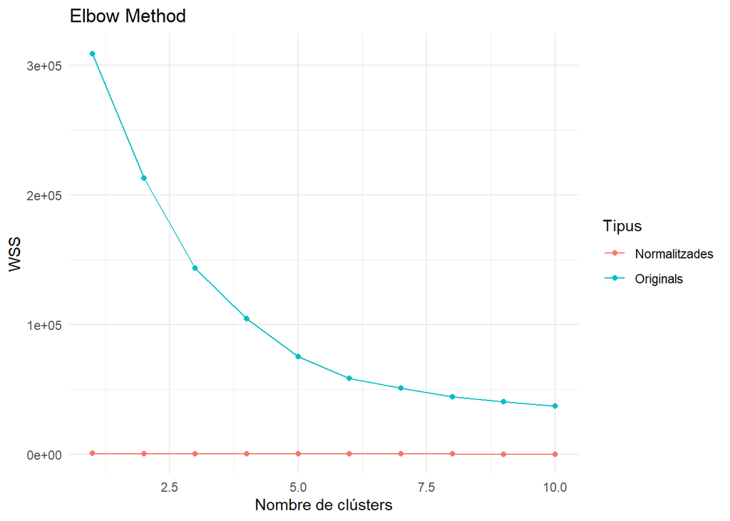

```r
library(tidyverse)
library(cluster)
library(gridExtra)
library(factoextra)
library(purrr)

# Llegir dataset
dades <- read.csv("Mall_Customers.csv")

# Seleccionem només variables numèriques útils per clustering
variables_numeriques <- dades %>%
  select(Age, Annual.Income..k.., Spending.Score..1.100.)

# Normalització (Z-score)
dades_norm <- scale(variables_numeriques) %>% as.data.frame()

# Funció per calcular WSS
wss <- function(k, data) {
  kmeans(data, k, nstart = 25)$tot.withinss
}

# Trams de k
k_values <- 1:10

# Calcular WSS
wss_orig <- map_dbl(k_values, wss, data = variables_numeriques)
wss_norm <- map_dbl(k_values, wss, data = dades_norm)

# Dibuixar gràfics
df_elbow <- tibble(
  k = rep(k_values, 2),
  WSS = c(wss_orig, wss_norm),
  Tipus = rep(c("Originals", "Normalitzades"), each = length(k_values))
)

ggplot(df_elbow, aes(k, WSS, color = Tipus)) +
  geom_line() + geom_point() +
  labs(title = "Elbow Method", x = "Nombre de clústers", y = "WSS") +
  theme_minimal()
```

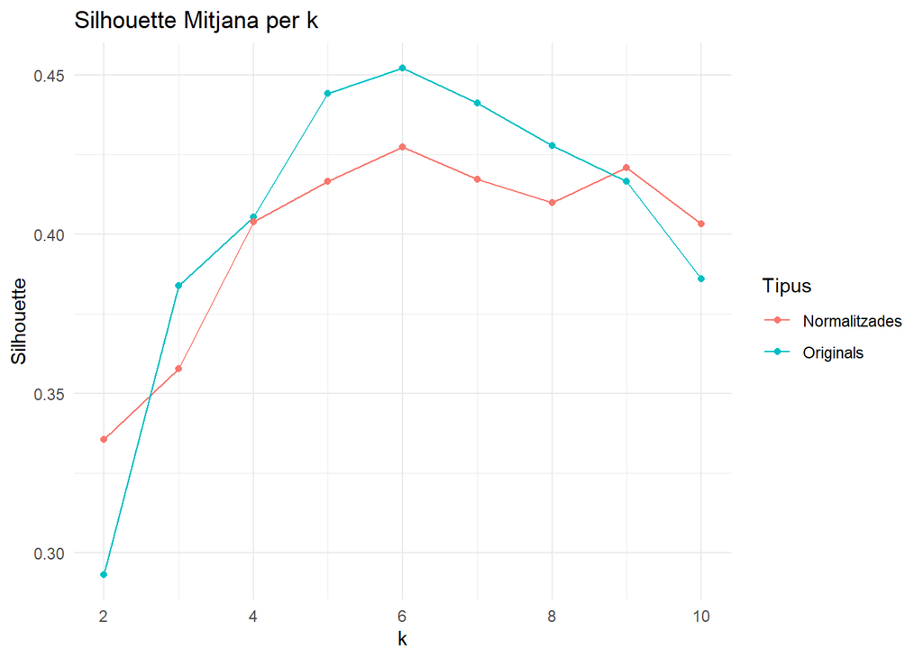

```r
# Funció silhouette mitjana
silhouette_avg <- function(k, data) {
  km <- kmeans(data, k, nstart = 25)
  ss <- silhouette(km$cluster, dist(data))
  mean(ss[, 3])
}

sil_orig <- map_dbl(2:10, silhouette_avg, data = variables_numeriques)
sil_norm <- map_dbl(2:10, silhouette_avg, data = dades_norm)

df_sil <- tibble(
  k = rep(2:10, 2),
  Silhouette = c(sil_orig, sil_norm),
  Tipus = rep(c("Originals", "Normalitzades"), each = 9)
)

ggplot(df_sil, aes(k, Silhouette, color = Tipus)) +
  geom_line() + geom_point() +
  labs(title = "Silhouette Mitjana per k", x = "k", y = "Silhouette") +
  theme_minimal()
```

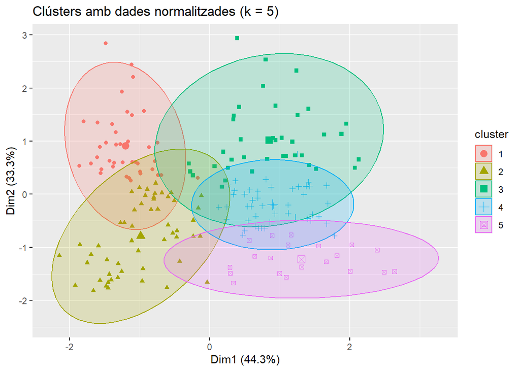

```r
library(factoextra)

# Aplicar k-means amb k = 5
set.seed(123)
km_norm <- kmeans(dades_norm, centers = 5, nstart = 25)

# Visualització amb factoextra
fviz_cluster(km_norm, data = dades_norm,
             geom = "point", ellipse.type = "norm",
             main = "Clústers amb dades normalitzades (k = 5)")
```

```r
print(wss_orig)
```

```
##  [1] 308812.78 212840.17 143342.75 104366.15  75350.78  58300.44  51082.54
##  [8]  44307.87  40567.96  37014.15
```

```r
print(wss_norm)
```

```
##  [1] 597.00000 387.43926 293.73618 204.19902 167.40634 133.19899 116.42650
##  [8] 103.26926  91.49705  81.32994
```

```r
print(sil_orig)
```

```
## [1] 0.2931661 0.3839350 0.4054630 0.4442860 0.4523444 0.4412552 0.4278636
## [8] 0.4167695 0.3860011
```

```r
print(sil_norm)
```

```
## [1] 0.3354719 0.3577934 0.4039583 0.4166434 0.4274281 0.4172319 0.4100894
## [8] 0.4208805 0.4032930
```

Hem fet una agrupació dels clients usant l’algorisme k-means, tant amb les dades originals com amb les dades normalitzades (on totes les variables tenen la mateixa escala). Per decidir quants grups són més adequats, hem mirat dues coses: com disminueix la variabilitat dins dels grups (mètode Elbow) i com de ben separats estan els grups (índex Silhouette).

## 4.2 Exercici 2 (10%)

```r
# Apliquem PAM (k-medoids) amb k = 5 sobre les dades normalitzades
set.seed(123)
pam_result <- pam(dades_norm, k = 5)

# Mostrem l'objecte pam
print(pam_result)
```

```
## Medoids:
##       ID        Age Annual.Income..k.. Spending.Score..1.100.
## [1,]  46 -1.0630677         -0.8208730             0.57312090
## [2,]  72  0.5834344         -0.4401341            -0.31753996
## [3,]  65  1.7288272         -0.4782080             0.03097951
## [4,] 176 -0.6335454          1.0447474             1.38633299
## [5,] 167  0.2254992          0.9685997            -1.16947643
## Clustering vector:
##   [1] 1 1 1 1 1 1 2 1 3 1 3 1 2 1 2 1 2 1 2 1 2 1 2 1 2 1 2 1 2 1 2 1 2 1 2 1 2
##  [38] 1 2 1 3 1 2 1 2 1 2 1 1 1 2 1 1 3 2 2 2 3 1 2 3 1 3 3 3 1 2 3 1 1 3 2 3 3
##  [75] 3 1 2 2 1 2 3 2 3 2 1 2 3 1 1 2 3 1 2 2 2 1 2 1 2 1 1 2 3 1 2 1 3 2 3 3 3
## [112] 1 2 1 1 1 3 2 2 2 1 2 2 4 5 4 5 4 5 4 5 4 5 4 5 4 5 4 5 4 5 4 5 4 5 4 5 4
## [149] 5 4 5 4 5 4 5 4 5 4 5 4 5 4 5 4 5 4 5 4 5 4 5 4 5 4 5 4 5 4 5 4 5 4 5 4 5
## [186] 4 5 4 5 4 5 4 5 4 5 4 5 4 5 4
## Objective function:
##     build      swap
## 0.8810328 0.8579594
##
## Available components:
##  [1] "medoids"    "id.med"     "clustering" "objective"  "isolation"
##  [6] "clusinfo"   "silinfo"    "diss"       "call"       "data"
```

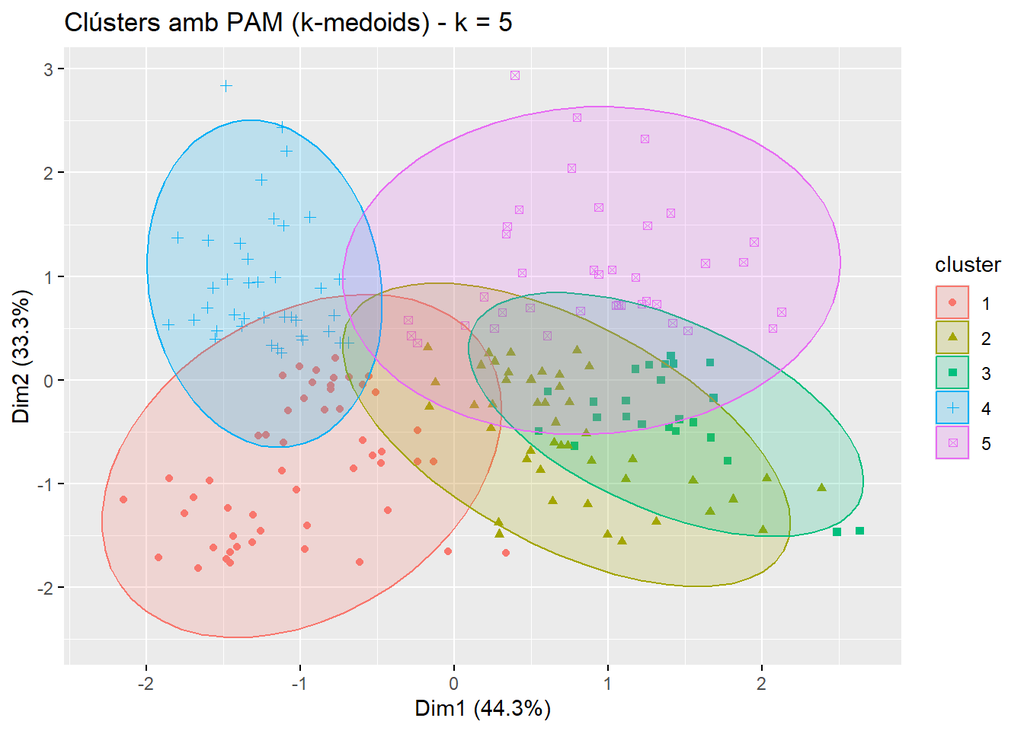

```r
# Visualització dels clústers
fviz_cluster(pam_result, geom = "point", ellipse.type = "norm",
             main = "Clústers amb PAM (k-medoids) - k = 5")
```

En aquest anàlisi, hem aplicat dues tècniques de clustering per agrupar els clients segons la seva edat, ingressos anuals i puntuació de despesa: primer l’algorisme k-means (Exercici 1), i després k-medoids (PAM) (Exercici 2), tots dos amb 5 grups.

El mètode k-means calcula els centres dels grups mitjançant la mitjana de les observacions. És ràpid i útil quan no hi ha valors atípics, però pot ser sensible a aquests. En canvi, el mètode k-medoids utilitza observacions reals com a centre del grup (medoids), i és més robust a valors extrems o anomalies.

En conclusió, els dos mètodes han identificat patrons clars en el comportament dels clients, però PAM pot ser una millor opció si sospitem de la presència d’outliers, ja que és més estable en aquestes situacions. Això demostra com diferents tècniques de clustering poden ser útils segons la naturalesa de les dades.

## 4.3 Exercici 3 (10%)

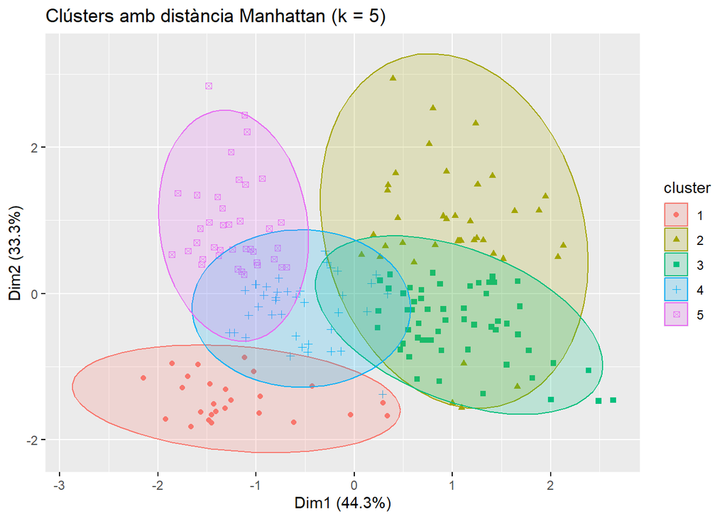

```r
library(cluster)
library(factoextra)

# Fem servir les dades normalitzades i apliquem PAM amb distància Manhattan, simulant k-means amb una altra mètrica
set.seed(123)
pam_manhattan <- pam(dades_norm, k = 5, metric = "manhattan")

# Visualització dels clústers amb la nova mètrica
fviz_cluster(pam_manhattan, data = dades_norm,
             geom = "point", ellipse.type = "norm",
             main = "Clústers amb distància Manhattan (k = 5)")
```

En aquest exercici, hem aplicat l’algorisme d’agrupació utilitzant el mètode PAM (Partitioning Around Medoids), però canviant la mètrica de distància: en lloc de la distància euclidiana (utilitzada per defecte a l’Exercici 1 amb k-means), hem utilitzat la distància Manhattan, que mesura la suma de les diferències absolutes entre les coordenades. Aquest canvi pot tenir impacte en la forma com es defineixen les agrupacions, especialment quan les dades tenen valors atípics o quan volem que la distància penalitzi menys grans desviacions puntuals.

Els resultats mostren que l’agrupació amb distància Manhattan dona lloc a una distribució lleugerament diferent dels punts dins dels clústers, especialment en els límits dels grups. En comparació amb el mètode de k-means de l’Exercici 1, els clústers són una mica més compactes i més estables, ja que PAM és menys sensible als valors extrems.

Respecte a l’Exercici 2, on també utilitzàvem PAM però amb distància euclidiana, aquest exercici ens permet veure com canviar la mètrica de distància pot modificar les assignacions dels individus als grups. Tot i que l’estructura general dels clústers es manté similar, alguns individus han canviat de clúster, la qual cosa reflecteix la sensibilitat dels mètodes de clustering a la definició de distància.

En conjunt, l’ús de distància Manhattan pot ser útil quan volem una agrupació més robusta a valors extrems o quan les dimensions tenen escales similars però interpretacions independents. Aquesta comparació ens ajuda a entendre que no només l’algorisme sinó també la mètrica escollida poden afectar notablement el resultat final del clustering.

## 4.4 Exercici 4 (10%)

```r
library(cluster)
library(dbscan)
```

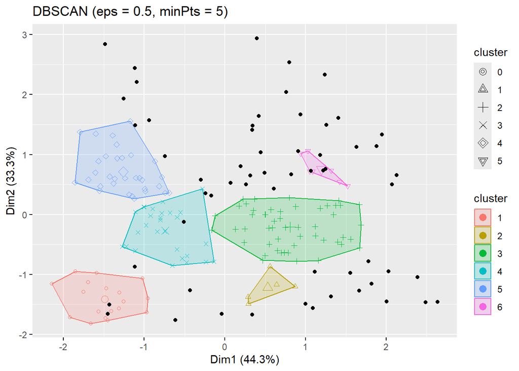

```r
library(factoextra)


# Càrrega de llibreria
library(dbscan)
library(factoextra)

# Aplicar DBSCAN amb eps = 0.5 i minPts = 5
res_db_05_5 <- dbscan(dades_norm, eps = 0.5, minPts = 5)

# Visualitzar resultats
fviz_cluster(res_db_05_5, dades_norm, geom = "point",
             main = "DBSCAN (eps = 0.5, minPts = 5)")
```

```r
# Veure quants clústers s'han trobat (0 = soroll)
table(res_db_05_5$cluster)
```

```
##
##  0  1  2  3  4  5  6
## 59 18  5 51 28 32  7
```

En aquest exercici s’ha aplicat l’algorisme DBSCAN (Density-Based Spatial Clustering of Applications with Noise), que permet identificar agrupacions en funció de la densitat dels punts, sense necessitat de fixar prèviament el nombre de clústers. S’han utilitzat els valors eps = 0.5 i minPts = 5. Amb aquests paràmetres, el model ha identificat 6 clústers reals (amb etiquetes del 1 al 6) i ha considerat 59 observacions com a soroll (etiqueta 0). Aquesta capacitat de detectar punts sorollosos és una diferència respecte als mètodes de partició com K-means i K-medians, que obliguen a assignar tots els punts a algun grup.

A diferència de K-means i K-medians, que assumeixen clústers amb forma esfèrica i de mida similar, DBSCAN permet capturar formes arbitràries i zones de diferent densitat. Això es fa evident en la distribució de punts: alguns clústers detectats són petits (com el clúster 2 amb només 5 punts) i d’altres força grans (com el clúster 3 amb 51 punts), cosa que mostra més flexibilitat a l’hora d’identificar estructures naturals en les dades. Tot i així, la dificultat de seleccionar bons valors d’eps i minPts fa que calgui provar diferents combinacions per optimitzar els resultats. A més, l’alta proporció de punts classificats com a soroll pot indicar que els paràmetres podrien ajustar-se millor per captar més estructura.

En resum, DBSCAN aporta una visió complementària als resultats obtinguts amb K-means i K-medians, especialment útil quan hi ha clústers amb formes o densitats diferents i quan es vol detectar soroll o valors atípics de forma automàtica.

## 4.5 Exercici 5 (10%)

Per crear un model que funcioni bé, primer cal ensenyar-li amb un conjunt de dades (anomenat entrenament). Però també és important provar-lo després amb dades noves que no hagi vist abans (anomenat test) per veure si realment aprèn i no només memoritza.

Per això hem dividit les dades en dos grups: un 70% per entrenar i un 30% per provar. Aquesta proporció és habitual perquè assegura que el model aprengui prou i que la prova sigui significativa. Hem fet la selecció de forma aleatòria per evitar biaixos i garantir que cada grup sigui representatiu.

```r
set.seed(123)

# Proporció d'entrenament i test
prop_entrenament <- 0.7  # 70% per entrenar
prop_test <- 0.3         # 30% per test

# Nombre d'observacions
n <- nrow(dades)

# Índexs per mostra entrenament
index_entrenament <- sample(seq_len(n), size = floor(prop_entrenament * n))

# Crear les mostres
dades_entrenament <- dades[index_entrenament, ]
dades_test <- dades[-index_entrenament, ]

# Imprimir nombre d'observacions a pantalla
cat("Mostra d'entrenament: ", nrow(dades_entrenament), " observacions\n")
```

```
## Mostra d'entrenament:  140  observacions
```

```r
cat("Mostra de test: ", nrow(dades_test), " observacions\n")
```

```
## Mostra de test:  60  observacions
```

## 4.6 Exercici 6 (20%)

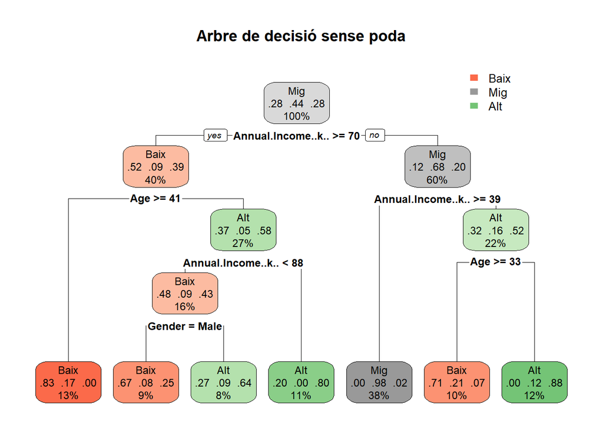

```r
library(rpart)
library(rpart.plot)
library(dplyr)

# Convertim la variable Spending.Score en categories
dades_entrenament <- dades_entrenament %>%
  mutate(SpendingCategory = case_when(
    Spending.Score..1.100. <= 33 ~ "Baix",
    Spending.Score..1.100. <= 66 ~ "Mig",
    TRUE ~ "Alt"
  )) %>%
  mutate(SpendingCategory = factor(SpendingCategory, levels = c("Baix", "Mig", "Alt")))

dades_test <- dades_test %>%
  mutate(SpendingCategory = case_when(
    Spending.Score..1.100. <= 33 ~ "Baix",
    Spending.Score..1.100. <= 66 ~ "Mig",
    TRUE ~ "Alt"
  )) %>%
  mutate(SpendingCategory = factor(SpendingCategory, levels = c("Baix", "Mig", "Alt")))

# Entrenar arbre de decisió sense poda
arbre <- rpart(SpendingCategory ~ Age + Annual.Income..k.. + Gender,
               data = dades_entrenament, method = "class")

# Mostrar arbre sense poda
rpart.plot(arbre, main = "Arbre de decisió sense poda")
```

```r
# Extracció de regles
arbre_regles <- path.rpart(arbre, nodes = rownames(arbre$frame[arbre$frame$var == "<leaf>",]))
```

```
##
##  node number: 4
##    root
##    Annual.Income..k..>=69.5
##    Age>=40.5
##
##  node number: 20
##    root
##    Annual.Income..k..>=69.5
##    Age< 40.5
##    Annual.Income..k..< 87.5
##    Gender=Male
##
##  node number: 21
##    root
##    Annual.Income..k..>=69.5
##    Age< 40.5
##    Annual.Income..k..< 87.5
##    Gender=Female
##
##  node number: 11
##    root
##    Annual.Income..k..>=69.5
##    Age< 40.5
##    Annual.Income..k..>=87.5
##
##  node number: 6
##    root
##    Annual.Income..k..< 69.5
##    Annual.Income..k..>=38.5
##
##  node number: 14
##    root
##    Annual.Income..k..< 69.5
##    Annual.Income..k..< 38.5
##    Age>=33
##
##  node number: 15
##    root
##    Annual.Income..k..< 69.5
##    Annual.Income..k..< 38.5
##    Age< 33
```

```r
cat("Algunes regles de l'arbre:\n")
```

```
## Algunes regles de l'arbre:
```

```r
for(i in seq_along(arbre_regles)) {
  cat(paste0("Regla ", i, ": ", paste(arbre_regles[[i]], collapse = " & "), "\n"))
}
```

```
## Regla 1: root & Annual.Income..k..>=69.5 & Age>=40.5
## Regla 2: root & Annual.Income..k..>=69.5 & Age< 40.5 & Annual.Income..k..< 87.5 & Gender=Male
## Regla 3: root & Annual.Income..k..>=69.5 & Age< 40.5 & Annual.Income..k..< 87.5 & Gender=Female
## Regla 4: root & Annual.Income..k..>=69.5 & Age< 40.5 & Annual.Income..k..>=87.5
## Regla 5: root & Annual.Income..k..< 69.5 & Annual.Income..k..>=38.5
## Regla 6: root & Annual.Income..k..< 69.5 & Annual.Income..k..< 38.5 & Age>=33
## Regla 7: root & Annual.Income..k..< 69.5 & Annual.Income..k..< 38.5 & Age< 33
```

```r
# Funció per a matriu de confusió i mètriques
calc_metrics <- function(conf_mat, class_name) {
  TP <- conf_mat[class_name, class_name]
  FN <- sum(conf_mat[, class_name]) - TP
  FP <- sum(conf_mat[class_name, ]) - TP
  TN <- sum(conf_mat) - TP - FN - FP

  sensibilitat <- TP / (TP + FN)
  especificitat <- TN / (TN + FP)
  precisio <- (TP + TN) / sum(conf_mat)

  return(list(
    classe = class_name,
    sensibilitat = sensibilitat,
    especificitat = especificitat,
    precisio = precisio
  ))
}

# Prediccions i matriu de confusió sense poda
predictions <- predict(arbre, dades_test, type = "class")
conf_mat <- table(Predicció = predictions, Real = dades_test$SpendingCategory)
print(conf_mat)
```

```
##          Real
## Predicció Baix Mig Alt
##      Baix    7   2   8
##      Mig     1  28   0
##      Alt     2   2  10
```

```r
# Mostrar mètriques per classe (sense poda)
classes <- levels(dades_test$SpendingCategory)
cat("\nMètriques sense poda:\n")
```

```
##
## Mètriques sense poda:
```

```r
for (cl in classes) {
  metrics <- calc_metrics(conf_mat, cl)
  cat(paste0("Classe: ", metrics$classe, "\n"))
  cat(paste0("  Sensibilitat: ", round(metrics$sensibilitat, 3), "\n"))
  cat(paste0("  Especificitat: ", round(metrics$especificitat, 3), "\n"))
  cat(paste0("  Precisió (Accuracy global): ", round(metrics$precisio, 3), "\n\n"))
}
```

```
## Classe: Baix
##   Sensibilitat: 0.7
##   Especificitat: 0.8
##   Precisió (Accuracy global): 0.783
##
## Classe: Mig
##   Sensibilitat: 0.875
##   Especificitat: 0.964
##   Precisió (Accuracy global): 0.917
##
## Classe: Alt
##   Sensibilitat: 0.556
##   Especificitat: 0.905
##   Precisió (Accuracy global): 0.8
```

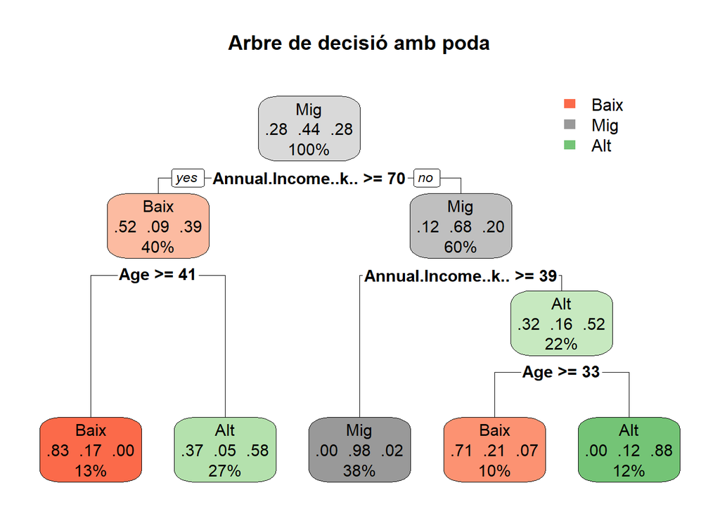

```r
# Poda de l'arbre (optimitzant cp)
cp_opt <- arbre$cptable[which.min(arbre$cptable[,"xerror"]), "CP"]
arbre_podat <- prune(arbre, cp = cp_opt)

# Mostrar arbre podat
rpart.plot(arbre_podat, main = "Arbre de decisió amb poda")
```

```r
# Prediccions i matriu de confusió amb poda
predictions_podat <- predict(arbre_podat, dades_test, type = "class")
conf_mat_podat <- table(Predicció = predictions_podat, Real = dades_test$SpendingCategory)
print(conf_mat_podat)
```

```
##          Real
## Predicció Baix Mig Alt
##      Baix    7   2   1
##      Mig     1  28   0
##      Alt     2   2  17
```

```r
# Mostrar mètriques per classe (amb poda)
cat("\nMètriques amb poda:\n")
```

```
##
## Mètriques amb poda:
```

```r
for (cl in classes) {
  metrics <- calc_metrics(conf_mat_podat, cl)
  cat(paste0("Classe: ", metrics$classe, "\n"))
  cat(paste0("  Sensibilitat: ", round(metrics$sensibilitat, 3), "\n"))
  cat(paste0("  Especificitat: ", round(metrics$especificitat, 3), "\n"))
  cat(paste0("  Precisió (Accuracy global): ", round(metrics$precisio, 3), "\n\n"))
}
```

```
## Classe: Baix
##   Sensibilitat: 0.7
##   Especificitat: 0.94
##   Precisió (Accuracy global): 0.9
##
## Classe: Mig
##   Sensibilitat: 0.875
##   Especificitat: 0.964
##   Precisió (Accuracy global): 0.917
##
## Classe: Alt
##   Sensibilitat: 0.944
##   Especificitat: 0.905
##   Precisió (Accuracy global): 0.917
```

## 4.7 Exercici 7 (10%)

```r
library(class)

# Crear la variable de classificació (target)
# Spending Score en 3 nivells
df$Categoria <- cut(df$Spending.Score..1.100.,
                    breaks = c(-Inf, 40, 70, Inf),
                    labels = c("Baix", "Mig", "Alt"))

# Separar el dataset en entrenament i test (70%-30%)
set.seed(123)
index <- sample(1:nrow(df), 0.7 * nrow(df))
train <- df[index, ]
test <- df[-index, ]

# Preparar dades per kNN (només numèriques i sense NA)
x_train <- scale(train[, c("Age", "Annual.Income..k..", "Spending.Score..1.100.")])
x_test <- scale(test[, c("Age", "Annual.Income..k..", "Spending.Score..1.100.")])
y_train <- train$Categoria
y_test <- test$Categoria

# Aplicar kNN (amb k = 5)
pred_knn <- knn(train = x_train, test = x_test, cl = y_train, k = 5)

# Confusion matrix
conf_mat <- table(Prediccio = pred_knn, Real = y_test)
print(conf_mat)
```

```
##          Real
## Prediccio Baix Mig Alt
##      Baix   12   3   0
##      Mig     0  26   0
##      Alt     0   1  18
```

```r
# Calcular mètriques manualment per cada classe
calcula_metrics <- function(conf, classe) {
  TP <- conf[classe, classe]
  FN <- sum(conf[, classe]) - TP
  FP <- sum(conf[classe, ]) - TP
  TN <- sum(conf) - TP - FP - FN

  sensitivitat <- round(TP / (TP + FN), 3)
  especificitat <- round(TN / (TN + FP), 3)
  accuracy <- round((TP + TN) / sum(conf), 3)

  cat("Classe:", classe, "\n")
  cat("  Sensibilitat:", sensitivitat, "\n")
  cat("  Especificitat:", especificitat, "\n")
  cat("  Precisió (Accuracy global):", accuracy, "\n\n")
}

# Aplicar mètriques per a cada classe
classes <- levels(y_test)
for (cl in classes) {
  calcula_metrics(conf_mat, cl)
}
```

```
## Classe: Baix
##   Sensibilitat: 1
##   Especificitat: 0.938
##   Precisió (Accuracy global): 0.95
##
## Classe: Mig
##   Sensibilitat: 0.867
##   Especificitat: 1
##   Precisió (Accuracy global): 0.933
##
## Classe: Alt
##   Sensibilitat: 1
##   Especificitat: 0.976
##   Precisió (Accuracy global): 0.983
```

## 4.8 Exercici 8 (10%)

### 4.8.1 Limitacions de les dades seleccionades per als models supervisats i no supervisats

Les dades utilitzades en aquest treball provenen de la base de dades Mall Customers, que conté informació bàsica com l’edat, el gènere, els ingressos anuals i una puntuació de despesa. Tot i que aquestes variables han permès construir models supervisats i no supervisats útils, també presenten limitacions que cal tenir en compte. En primer lloc, el conjunt de dades és relativament petit i senzill, fet que pot dificultar la generalització dels models, especialment els supervisats, que requereixen molts exemples etiquetats per aprendre bé. A més, les variables disponibles poden no capturar tota la complexitat del comportament del client, deixant fora factors importants com preferències personals, historial de compres o context socioeconòmic. Aquesta manca de diversitat pot fer que els models, tant supervisats com no supervisats, s’ajustin massa al conjunt concret de dades i no siguin robustos en altres contextos. Per als models no supervisats, com el clustering, la presència de valors extrems o la manca d’una estructura clara en les dades pot portar a agrupacions difícils d’interpretar o poc útils. Per tant, tot i que el treball mostra que es poden extreure patrons rellevants amb aquestes dades, els resultats s’han d’interpretar amb prudència i tenint present que l’ús de dades més riques i variades podria millorar significativament la qualitat i l’aplicabilitat dels models.

### 4.8.2 Riscos de l’ús del model i conclusions principals

En aquest treball, s’han aplicat models supervisats i no supervisats sobre la base de dades Mall Customers per analitzar el comportament dels clients en funció de variables com l’edat, el gènere, els ingressos anuals i la puntuació de despesa. Tot i que aquests models poden ser útils per identificar patrons de consum i fer prediccions, el seu ús comporta certs riscos que cal considerar. Per exemple, si les dades no són representatives o presenten biaixos (com una distribució desigual entre grups d’edat o gènere), el model pot oferir resultats esbiaixats o injustos. A més, un model massa adaptat a les dades d’entrenament pot perdre capacitat de generalització i funcionar malament amb nous clients. També cal tenir en compte que els models poden quedar obsolets amb el temps si els hàbits dels consumidors canvien i les dades no s’actualitzen. Finalment, molts models actuen com a “caixa negra”, cosa que dificulta entendre per què s’ha fet una predicció determinada. Per tot això, és important aplicar aquests models amb sentit crític, assegurant una bona qualitat de les dades, revisant-los periòdicament i buscant sempre la màxima transparència i interpretabilitat per garantir que les decisions derivades siguin justes i útils.